# Starting with Raw Data

## Image formats: DICOM

DICOM (Digital Imaging and Communications in Medicine) format

- Standardized way of representing images
- Usually how data is given either from scanner or hospital PACS (picture archiving and communication system) system
- 2 integral pieces: Image data (in pixels) and header (meta-data (data about data))
  - Think of a JPEG/bitmap and a text file

## DICOM pixel data

The pixel data in a DICOM file is a matrix (fixed number of rows and columns).

One DICOM file represents one “slice” of the brain.

The `oro.dicom` package is good for reading in this data.

```r
library(oro.dicom)
library(divest)
dcm_file = system.file("extdata", "testdata",
                       "01.dcm", package = "divest")
slice = readDICOM(dcm_file)
class(slice)
```

```
[1] "list"
```

## readDICOM output

The output is a list with 2 elements: the DICOM header (`hdr`) and image (`img`) information, both of which are lists.

Each element of `hdr` has a `data.frame`, and the elements of `img` are matrices:

```r
names(slice)
```

```
[1] "hdr" "img"
```

```r
class(slice[["hdr"]])
```

```
[1] "list"
```

```r
class(slice$hdr[[1]])
```

```
[1] "data.frame"
```

```r
class(slice$img)
```

```
[1] "list"
```

```r
class(slice$img[[1]])
```

```
[1] "matrix"
```

## Display DICOM Image using `image` command

(We transpose the data using `t()` so the image faces “up” instead of “right”.)

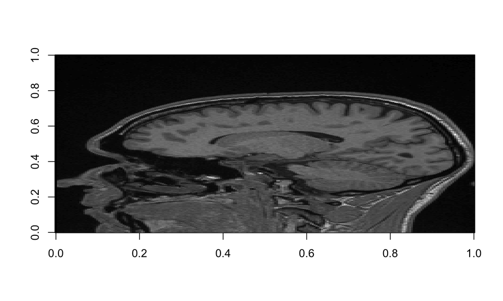

```r
image(t(slice$img[[1]]), col=gray(0:64/64))
```

## DICOM Header Information

What about the header?

There are many fields, for example pixelSpacing, which is the dimensions (x and y) of a pixel in millimeters (mm):

```r
hdr = slice$hdr[[1]]
hdr[ hdr$name == 'PixelSpacing', "value"]
```

```
[1] "1 1"
```

## DICOM Header Information

Many fields - most important are tag, name and value:

```r
head(hdr)
```

```
  group element                       name code length
1  0002    0000                GroupLength   UL      4
2  0002    0001 FileMetaInformationVersion   OB      2
3  0002    0002    MediaStorageSOPClassUID   UI     26
4  0002    0003 MediaStorageSOPInstanceUID   UI     56
5  0002    0010          TransferSyntaxUID   UI     20
6  0002    0012     ImplementationClassUID   UI     18
                                                     value sequence
1                                                      188
2                                                     \001
3                                1.2.840.10008.5.1.4.1.1.4
4 1.3.12.2.1107.5.2.30.25471.30000008091010241767100006233
5                                      1.2.840.10008.1.2.1
6                                        1.3.12.2.1107.5.2
```

## DICOM Header Information

You can reshape this into a “wide” format using `dicomTable`

```r
wide = oro.dicom::dicomTable(slice$hdr)
wide[, 1:5]
```

```
  0002-0000-GroupLength 0002-0001-FileMetaInformationVersion
1                   188                                 \001
  0002-0002-MediaStorageSOPClassUID
1         1.2.840.10008.5.1.4.1.1.4
                      0002-0003-MediaStorageSOPInstanceUID
1 1.3.12.2.1107.5.2.30.25471.30000008091010241767100006233
  0002-0010-TransferSyntaxUID
1         1.2.840.10008.1.2.1
```

## Multiple DICOM files

We have discussed only one slice of the brain. What about multiple slices? If you pass a directory into `readDICOM`, it will read in all DICOM files in that directory.

```r
dcm_fol = system.file("extdata", "testdata", package = "divest")
all_slices = readDICOM(dcm_fol)
n = names(all_slices$hdr)
keep = grep("0(1|2).dcm", n)
all_slices$hdr = all_slices$hdr[keep]
all_slices$img = all_slices$img[keep]
```

## Multiple DICOM files: header reshaping

When you pass in multiple headers, you have a row for each file:

```r
wide = oro.dicom::dicomTable(all_slices$hdr)
wide[, 1:5]
```

```
       0002-0000-GroupLength 0002-0001-FileMetaInformationVersion
01.dcm                   188                                 \001
02.dcm                   188                                 \001
       0002-0002-MediaStorageSOPClassUID
01.dcm         1.2.840.10008.5.1.4.1.1.4
02.dcm         1.2.840.10008.5.1.4.1.1.4
                           0002-0003-MediaStorageSOPInstanceUID
01.dcm 1.3.12.2.1107.5.2.30.25471.30000008091010241767100006233
02.dcm 1.3.12.2.1107.5.2.30.25471.30000008091010241767100006232
       0002-0010-TransferSyntaxUID
01.dcm         1.2.840.10008.1.2.1
02.dcm         1.2.840.10008.1.2.1
```

## NIfTI

Now that we have multiple slices read in, we can convert it to a 3-dimensional (3D) array, where you can think of the array as stacking each slice (which is a matrix) on top of each other. If each DICOM is a piece of paper, the 3D array is a stack of paper.

The way we store this 3D array is in the NIfTI (Neuroimaging Informatics Technology Initiative) format.

## DICOM vs. NIfTI

|  | DICOM | NIfTI |
| --- | --- | --- |
| File extension: | .dcm | .nii or .nii.gz (compressed) |
| Each file is a: | slice of the brain | 3D image of brain |
| Header information: | Many fields, protected health information, hospital-related meta-data | Image meta-data, no patient information |
| Different Images | Different Folders | Different Files (can be same directory) |

## NIfTI

We can convert this list of header information and image information to a `nifti` object (an R object) with the `dicom2nifti` command:

```r
nii = dicom2nifti(all_slices)
dim(nii); class(nii)
```

```
[1]   2 224 256
```

```
[1] "nifti"
attr(,"package")
[1] "oro.nifti"
```

We can see that this `nii` object is indeed a `nifti` object and has 3 dimensions.

## Writing out NIfTI file

The `writenii` command from the `neurobase` package can write out this `nifti` object to a NIfTI file (based on `writeNIfTI` from `oro.nifti`):

```r
library(neurobase)
writenii(nim = nii, filename = "Output_3D_File")
list.files(pattern = "Output_3D_File")
```

```
[1] "Output_3D_File.nii.gz"
```

Note that the extension is `.nii.gz`, which is a compressed NIfTI file, which saves disk space for storage.

You can output a non-compressed file using the argument `gzipped=FALSE`.

(NB: The filename argument in `writeNIfTI` should NOT have an extension, but can in `writenii`)

## `divest`, `dcm2niir` and `dcm2niix`

`dcm2niix` is a piece of software from Dr. Chris Rorden that can convert nearly any DICOM format to a NIfTI. It is our recommended way of converting DICOM to NIfTI files.

- `divest` - wraps `dcm2niix` code in Rcpp (newer, still being tested)
- `dcm2niir` - wraps the binary `dcm2niix` program. This is not as cross-platform (Linux and Mac OSX only), but may handle some cases a bit better than `divest` (until that package matures).

In each, you specify a `path` argument:

```r
library(dcm2niir)
d = dcm2nii(path)
library(divest)
res = readDicom(path, interactive = FALSE)
```

## Other DICOM converters

Although our main goal is to analyze neuro data with the fewest pieces of software, we are pragmatic and use existing software if it works well.

The software converts DICOM files to NIfTI files, and can handle many different formats and file types.

In general, the format we will be using will be NIfTI, and we will store out data in compressed format, so extensions of our images will be `.nii.gz`.

## Other formats

- For Philips scanners, files from the scanner are PAR/REC and not DICOM, but can still be converted using `dcm2niix`. [r2a](http://sourceforge.net/projects/r2agui/) can also convert these to NIfTI.
- NIfTI format was based on ANALYZE format where the header and image were in separate `.hdr` and `.img` files. This is an older fromat and we will not use this way of storing data because 1) NIfTI can have one file with both header and image information, and 2) Can be stored as compressed .nii.gz files.
- NRRD (Nearly Raw Raster Data) is another format similar to NIfTI. Much of the neuroimaging software can read in both NRRD and NIfTI files, but NIfTI is much more common.

## Conclusions

In this course, we will be using NIfTI images, and will be using `readnii` to read them in, and `writenii` to write them out.

- Images will be in gzipped format (extension `.nii.gz`)
- Additional software (e.g. FSL) will be useful to reorient the data to a specified orientation before reading
- DICOM images can be converted robustly using `divest` or `dcm2niix`

## Website

http://johnmuschelli.com/imaging_in_r